# Mapeamento do Zika Vírus no Brasil

Fernando Tsutomu Hara

14/06/2020

## Mapeamento do Zika Vírus

Este projeto tem como objetivo fazer um mapeamento do zika vírus no brasil, analizando através de gráficos como ele cresceu em cada região e estado do país durante o ano de 2016.

## Leitura dos Arquivos

Para realizar este projeto foram coletados 08 arquivos do tipo csv do site oficial do governo federal, onde nos mostra quantas ocorrências houveram por cada localodade. Após a leitura dos arquivos vamos transformá-los em um único data frame.

```r
# Lendo os arquivos.
df1 <- read.csv("Epidemiological_Bulletin-2016-04-02.csv")
df2 <- read.csv("Epidemiological_Bulletin-2016-04-23.csv")
df3 <- read.csv("Epidemiological_Bulletin-2016-04-30.csv")
df4 <- read.csv("Epidemiological_Bulletin-2016-05-07.csv")
df5 <- read.csv("Epidemiological_Bulletin-2016-05-14.csv")
df6 <- read.csv("Epidemiological_Bulletin-2016-05-21.csv")
df7 <- read.csv("Epidemiological_Bulletin-2016-05-28.csv")
df8 <- read.csv("Epidemiological_Bulletin-2016-06-11.csv")

# Transformação em um único Data Frame
df <- rbind(df1, df2, df3, df4, df5, df6, df7, df8)

# Verificando os tipos de cada coluna
str(df)
```

```
## 'data.frame':    264 obs. of  9 variables:
##  $ report_date     : Factor w/ 8 levels "2016-04-02","2016-04-23",..: 1 1 1 1 1 1 1 1 1 1 ...
##  $ location        : Factor w/ 33 levels "Brazil","Brazil-Acre",..: 31 23 2 5 24 15 4 28 30 11 ...
##  $ location_type   : Factor w/ 3 levels "country","region",..: 2 3 3 3 3 3 3 3 2 3 ...
##  $ data_field      : Factor w/ 1 level "zika_reported": 1 1 1 1 1 1 1 1 1 1 ...
##  $ data_field_code : Factor w/ 1 level "BR0011": 1 1 1 1 1 1 1 1 1 1 ...
##  $ time_period     : logi  NA NA NA NA NA NA ...
##  $ time_period_type: logi  NA NA NA NA NA NA ...
##  $ value           : int  6295 618 375 1520 44 771 74 2893 30286 1202 ...
##  $ unit            : Factor w/ 1 level "cases": 1 1 1 1 1 1 1 1 1 1 ...
```

## Limpeza e Organização dos Dados

Agora faremos a limpeza dos dados, primeiro vamos excluir duas colunas que contêm apenas valores NA, logo depois vamos renomear as colunas e fazer algumas outras modificações que serão explicados nos comentários.

```r
# Como as colunas time_period e time_period_type têm apenas valores nulos, vou excluir-las.
df <- df[, -(6:7)]

# A coluna report_date está como factor. Vou colocá-la como date.
df$report_date <- as.Date(df$report_date)

# Vou modificar os nomes das colunas para ficar mais fácil a manipulação.
library(dplyr)
library(tidyr)

df <- df %>%
  rename(
    data = report_date,
    local = location,
    tipo_local = location_type,
    dado_reportado = data_field,
    cod_dado_reportado = data_field_code,
    quantidade = value,
    unidade = unit
  )

# Vamos mudar esse data frame para ter uma visualização melhor dos dados.
# Primeiro vou excluir as linhas da variável local que contenha as regiões e o pais (Brasil), pois esses dados acabam ficando redundantes. Depois farei o split das coluna local crindo uma coluna pais e outra estado. E por fim criarei a coluna região. Assim fica mais fácil a manipulação dos dados.

# Excluindo linhas
reg <- c('Norte', 'Nordeste', 'Sudeste', 'Sul', 'Centro-Oeste', 'Brazil')
for(i in reg){
  df <- df[df$local != i, ]
}


# Dividindo as colunas por estado e pais
df <- df %>%
  separate(local, c("pais", "estado"), "-")

# Criando a coluna região
norte <- c('Rondonia', 'Amazonas', 'Para', 'Tocantins', 'Acre',
           'Roraima', 'Amapa')
nordeste <- c('Maranhao', 'Piaui', 'Ceara', 'Rio_Grande_do_Norte', 'Paraiba',
              'Pernambuco', 'Alagoas', 'Sergipe', 'Bahia')
sudeste <- c('Minas_Gerais', 'Espirito_Santo', 'Rio_de_Janeiro', 'Sao_Paulo')
sul <- c('Parana', 'Santa_Catarina', 'Rio_Grande_do_Sul')
centro_oeste <- c('Mato_Grosso_do_Sul', 'Mato_Grosso', 'Goias',
                  'Distrito_Federal')
df$regiao <- ifelse(df$estado %in% norte, "norte",
                    (ifelse(df$estado %in% nordeste, "nordeste",
                            (ifelse(df$estado %in% sudeste, "sudeste",
                                     (ifelse(df$estado %in% sul, 'sul',
                                             'centro_oeste')))))))
# Excluindo a coluna tipo_local
df <- df[, -4]

# Reorganizando as colunas
df <- df[, c(1,3,8,2,6,4,5,7)]
```

## Análise e Interpretação dos Dados

Agora faremos a análise e interpretação dos dados, onde criaremos um gráfico de linhas demonstrando o crescimento do vírus zika por região, um gráfico de barras demonstrando o número do vírus por região também e por último um mapa interativo do brasil onde poderemos ver o número de ocorrências por estado, região e país.

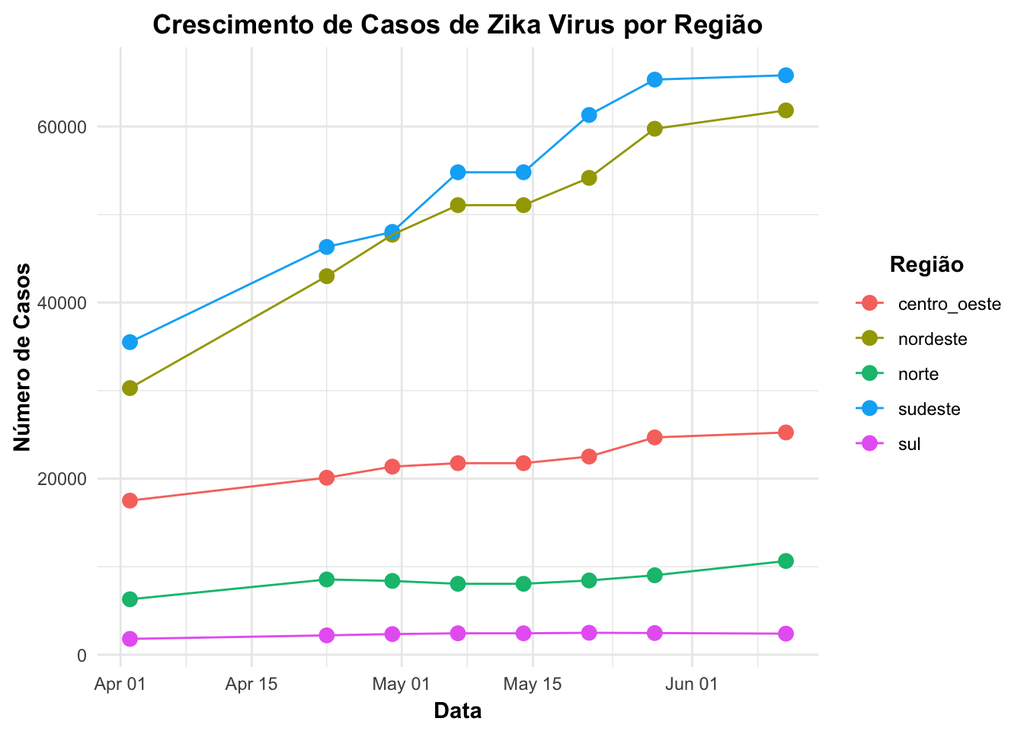

```r
# Vamos criar um novo data frame a partir do original para fazer o gráfico de linha.
qnt_por_regiao <- df %>%
  group_by(data, regiao) %>%
  summarise(quant = sum(quantidade))

# Para a realização dos dois primeiros gráficos vamos utilizar a biblioteca ggplot2 e hrbrthemes
library(ggplot2)
library(hrbrthemes)

# Criação do Gráfico de linhas.
ggplot(qnt_por_regiao, aes(x=data, y=quant, color=regiao)) +
  geom_point(size=3) +
  geom_line() +
  labs(title="Crescimento de Casos de Zika Virus por Região", x ="Data",
       y = "Número de Casos", color = "Região") +
  theme_minimal() +
  theme(plot.title=element_text(hjust=0.5, vjust=0.5, face='bold'),
        axis.title.x = element_text(hjust=0.5, vjust=0.5, face='bold'),
        axis.title.y = element_text(hjust=0.5, vjust=0.5, face='bold'),
        legend.title =element_text(hjust=0.5, vjust=0.5, face='bold'))
```

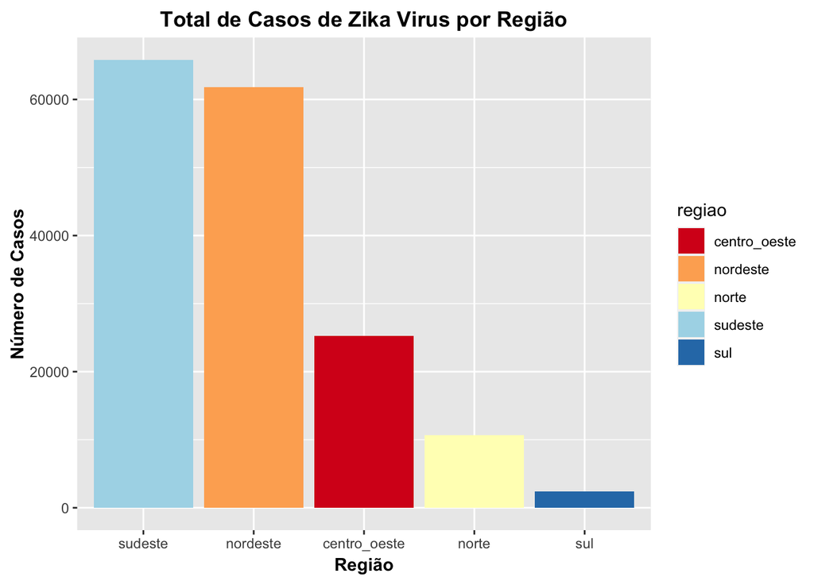

```r
# Podemos perceber que nas regiões suldeste e nordeste foram onde tiveram o maior número de ocorrência da doença do zika vírus, enquanto que nas outras regiões o número foi bem menor.

# Criação do gráfico de barras.
# Para criar esse gráfico vamos filtrar o data frame de forma que teremos apenas os dados da última atualização, onde tem todas as ocorrências.
df %>%
  filter(data == max(qnt_por_regiao$data)) %>%
  ggplot(aes(reorder(regiao, -quantidade, sum), quantidade, fill=regiao)) +
    geom_bar(stat = 'identity') +
    scale_fill_brewer(palette = "RdYlBu") +
    labs(title="Total de Casos de Zika Virus por Região", x ="Região",
         y = "Número de Casos") +
    theme(plot.title=element_text(hjust=0.5, vjust=0.5, face='bold'),
          axis.title.x = element_text(hjust=0.5, vjust=0.5, face='bold'),
          axis.title.y = element_text(hjust=0.5, vjust=0.5, face='bold'))
```

```r
# Como vimos no gráfico acima, as regiões suldeste e nordeste foram as que tiveram mais ocorrências da doença.

# Criação do Mapa interativo
# Para criar o mapa vamos criar uma nova coluna no data frame que contenha as silgas de cada estado.
df$sigla_estado <- sapply(df$estado,
                         function(col){
                           if(col == 'Acre')
                             return('AC')
                           else if(col == 'Alagoas')
                             return('AL')
                           else if(col == 'Amazonas')
                             return('AM')
                           else if(col == 'Amapa')
                             return('AP')
                           else if(col == 'Bahia')
                             return('BA')
                           else if(col == 'Ceara')
                             return('CE')
                           else if(col == 'Distrito_Federal')
                             return('DF')
                           else if(col == 'Espirito_Santo')
                             return('ES')
                           else if(col == 'Goias')
                             return('GO')
                           else if(col == 'Maranhao')
                             return('MA')
                           else if(col == 'Minas_Gerais')
                             return('MG')
                           else if(col == 'Mato_Grosso_do_Sul')
                             return('MS')
                           else if(col == 'Mato_Grosso')
                             return('MT')
                           else if(col == 'Para')
                             return('PA')
                           else if(col == 'Paraiba')
                             return('PB')
                           else if(col == 'Pernambuco')
                             return('PE')
                           else if(col == 'Piaui')
                             return('PI')
                           else if(col == 'Parana')
                             return('PR')
                           else if(col == 'Rio_de_Janeiro')
                             return('RJ')
                           else if(col == 'Rio_Grande_do_Norte')
                             return('RN')
                           else if(col == 'Rondonia')
                             return('RO')
                           else if(col == 'Roraima')
                             return('RR')
                           else if(col == 'Rio_Grande_do_Sul')
                             return('RS')
                           else if(col == 'Santa_Catarina')
                             return('SC')
                           else if(col == 'Sergipe')
                             return('SE')
                           else if(col == 'Sao_Paulo')
                             return('SP')
                           else
                             return('TO')
                           })

# Agora vamos ler o arquivo csv, que contém as latitudes e longitudes de cada estado brasileiro.
lat_long_estados <- read.csv("lat_long_estados.csv", sep=";")

# Transformação da coluna uf para o tipo caracter.
lat_long_estados$uf <- as.character(lat_long_estados$uf)

# Criação de um novo data frame com o estado, número de casos, latidude e longitude.
map <- df %>%
  inner_join(lat_long_estados, by=c('sigla_estado' = 'uf')) %>%
  filter(data==max(data))
str(map)
```

```
## 'data.frame':    27 obs. of  11 variables:
##  $ data              : Date, format: "2016-06-11" "2016-06-11" ...
##  $ estado            : chr  "Rondonia" "Acre" "Amazonas" "Roraima" ...
##  $ regiao            : chr  "norte" "norte" "norte" "norte" ...
##  $ pais              : chr  "Brazil" "Brazil" "Brazil" "Brazil" ...
##  $ quantidade        : int  898 846 3713 83 2121 189 2795 2840 241 2358 ...
##  $ dado_reportado    : Factor w/ 1 level "zika_reported": 1 1 1 1 1 1 1 1 1 1 ...
##  $ cod_dado_reportado: Factor w/ 1 level "BR0011": 1 1 1 1 1 1 1 1 1 1 ...
##  $ unidade           : Factor w/ 1 level "cases": 1 1 1 1 1 1 1 1 1 1 ...
##  $ sigla_estado      : chr  "RO" "AC" "AM" "RR" ...
##  $ latitude          : num  -10.83 -8.77 -3.47 1.99 -3.79 ...
##  $ longitude         : num  -63.3 -70.5 -65.1 -61.3 -52.5 ...
```

```r
map <- map[, c('estado', 'quantidade', 'latitude', 'longitude')]

# Para criar o  mapa precisamos repetir o número de linhas para cada estado de acordo com o número de ocorrências.
num_of_times_to_repeat <- map$quantidade
map <- map[rep(seq_len(nrow(map)),num_of_times_to_repeat),]

# Para a criação usaremos a biblioteca leaflet.
library(leaflet)

# Criação do Mapa
leaflet(map) %>%
  addTiles() %>%
  addMarkers(clusterOptions = markerClusterOptions())
```

```
## Assuming "longitude" and "latitude" are longitude and latitude, respectively
```

[interactive chart not shown]

## Conclusão.

Este projeto nos mostra como podemos utilizar gráficos para interpretar dados de forma diferente e com o mapa interativo as informações ficam de uma maneira fácil e elegantes para apresentar os dados.